# Borrador

Jennifer Salazar

# Falta hacer esto

Defina la variable de la serie, su unidad de medida, su construcción e interpretacion de sus cifras, perıodos observados, frecuencia de observacion, total de observaciones y fuente de los datos.

# Librerias utiles

```r
library(forecast)
library(TSA)
library(fANCOVA)
Datos20=read.table("anex-EMMET-dic2019-Fabricacion de otros productos quimicos (1).csv",header=T,sep=";",skip=14,dec=",",colClasses=c(rep("NULL",4),"numeric",rep("NULL",6)))
Datos20=ts(Datos20,freq=12,start=c(2001,1))
```

# Análisis descriptivo:

Se Consideran los datos sobre el índice de producción nominal de la clase otros productos quimicos sector de manufactura, de enero de 2001 a diciembre de 2019 (N=228), año base 2018. Ver Figura 1(a).

## Descomposición aditiva (tendencia)

```r
Tt=decompose(Datos20)$trend
```

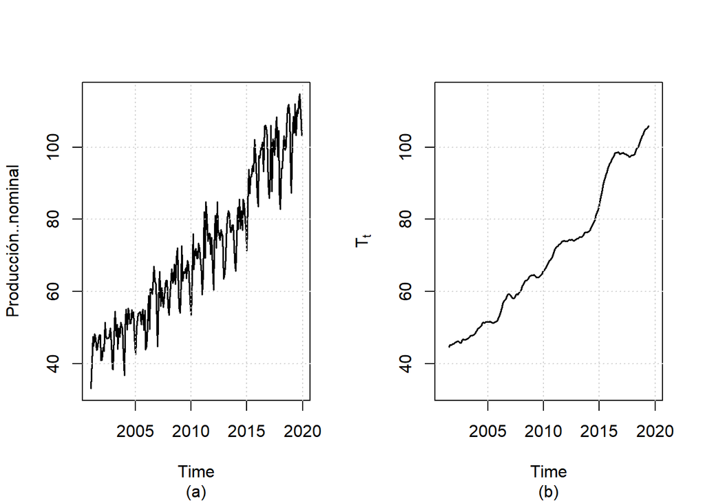

```r
par(mfrow=c(1,2))
plot(Datos20, sub="(a)", lwd=1.5)
grid()
plot(Tt,ylim=c(min(Datos20),max(Datos20)), sub="(b)", lwd=1.5, ylab=expression(T[t]))
grid()
```

**Figura 1.** (a) Índice de producción nominal de en Colombia sector manufactura, Clase industrial: otros productos quimicos. Enero 2001 - diciembre 2019; (b) Tendencia según el filtro de descomposición aditiva.

De la Figura 1(a) se deduce la presencia de estacionalidad y tendencia aditivas, es aditiva dado que su varianza es constante alrededor de su trayectoria de largo plazo(tendencia). En la Figura 1(b) es visible que la serie es de tendencia creciente y que existen ciclos.

## grafico de boxplots comparativos de la distribucion de la serie versus perıodos del año calendario

## Periodograma

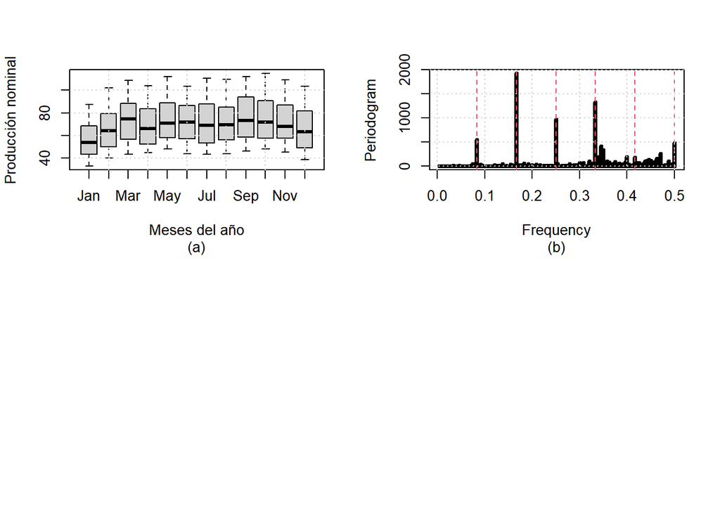

```r
par(mfrow=c(2,2))
boxplot(Datos20~cycle(Datos20), names=month.abb, ylab="Producción nominal", xlab = "Meses del año", sub="(a)")
grid()
periodogram(diff(Datos20),lwd=4, sub="(b)") #periodograma sobre los logaritmos diferenciados
abline(v=c(1:6)/12,col=2,lty=2)
grid()
```

**Figura 2.** (a) Boxplots: distribución por meses de la serie. (b) Periodograma sobre las diferencias de la serie.

De la figura 2(a) en los boxplots comparativos se ve cómo la media (o mediana) de la distribución de la serie según el periodo del año, cambia a lo largo de un año calendario siendo menor en los meses de enero, febrero, abril y diciembre comparados con el resto del año. Tiene un crecimiento de enero a marzo y luego vuelve y baja en abril para volver a subir en mayo manteniendose relativamente al mismo nivel en los siguientes meses hasta noviembre, para luego decaer en diciembre y retormar el siguiente año; se confirma que existe un patrón periódico anual con una forma constante en el tiempo.

De la figura 2(b) Periodograma: muestra la asociacion de la serie con cinco componentes periodicas (valor alto del periodograma en esas frecuencias): en las frecuencias 1/12 y 2/12, 3/12, 4/12, 6/12. El periodograma reafirma la existencia de componente estacional.

# justifique por que existe componente estacional y si su forma es constante o no en el tiempo.

- Mediante el gráfico de la serie vs el tiempo se ve un patrón que se repite cada año; pues en cada año se observa que en los meses del inicio y del final el índice de producción nominal es bajo y tiene aproximadamente 2 picos de decaimiento en el transcurso del año.
- Dado que en el gráfico de boxplot al menos una de las medias de los meses cambia respecto al resto de los meses del año calendario, por lo tanto se concluye que cada periodo en que se divide el año calendario determina una estación, la cual tiene incidencia sobre el valor medio de la serie, por ellos se dice que existe la componente estacional.
- Mediante el periodograma se resalta que hay una asociación de la serie con fenomenos periodicos, indicando la existencia de una componente estacional.

## Es la estacionalidad constante o no en el tiempo:

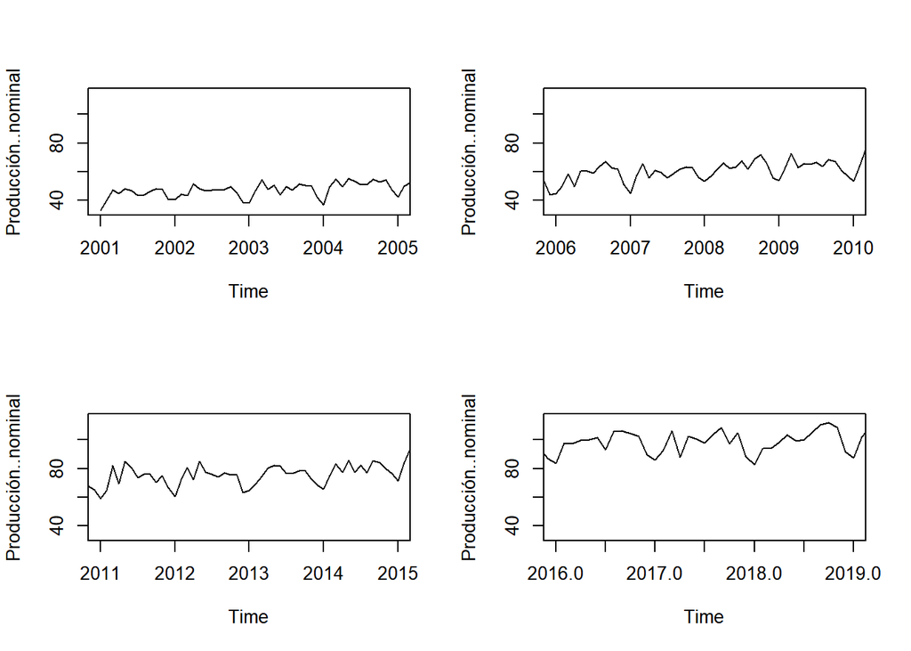

```r
par(mfrow=c(2,2))
plot(Datos20, xlim=c(2001,2005))
plot(Datos20, xlim=c(2006,2010))
plot(Datos20, xlim=c(2011,2015))
plot(Datos20, xlim=c(2016,2019))
```

## la tendencia se puede ajustar globalmente o si es local.

- La tendencia de la serie es global ya que se puede ajustar una curva suave creciente en todos los tiempos de la serie, También se puede ajustar modelos locales para comparar los ajustes y pronosticos respecto a la ajuste global.

## identificacion de posibles ciclos y cambios estructurales.

- Hay presencia de ciclos en la serie a tráves del tiempo ya que al aplicar la descomposición aditiva y obtener la tendencia, no se observa una curva suave que describa la tendencia de la serie.
- Hay aproximadamente entre 4 y 5 ciclos en la serie a través del tiempo (montañas).
- Parace haber posible cambio estructural en la serie en el 2015 ya que el nivel de la serie cambia un poco a partir de ese año.

# Modelos propuestos

$$\text{Tabla 1. Ecuación de los modelos propuestos}$$
$$\begin{array}{|c|}
\hline
\text{ Modelo 1: Modelo cuadrático estacional con indicadoras, mes de referencia diciembre}\\
Y_t=\beta_0+\beta_1t+\beta_2t^2+\sum_{i=1}^{11}\delta_iI_{i,t}+E_t, ~~~ E_t \sim iid N(0, \sigma^2)\\
\hline
\text{Modelo 2: Modelo cúbico estacional con indicadoras, mes de referencia diciembre}\\
Y_t=\beta_0+\beta_1t+\beta_2t^2+\beta_3t^3+\sum_{i=1}^{11}\delta_iI_{i,t}+E_t, ~~~ E_t \sim iid N(0, \sigma^2)\\
\hline
\text{Modelos 3: Descomposición aditiva & Loess cuadrático}\\
\text{En la vecindad de un tiempo} ~t_k~ \text{donde se quiere ajustar}
Y_t = \beta_{0,k} + \beta_{1,k}t + \beta_{2,k}t^2 + \sum_{i=1}^{12}\delta_i I_{i,t} + E_t, ~~ E_t \sim iid N(0,\sigma^2) \\
\text{para todo t vecino a} ~~t_k,~~ \text{con} \sum_{i=1}^{12}\delta_i=0,~~~ \beta_{0,k},~\beta_{1,k}~y~\beta_{2,k} \text{los parametros de la parabola local en la vecindad de} t_k\\
\hline
\text{Modelo 4: Suavizamiento exponencial Holt-Winters aditivo}\\
Y_{t+h} = \beta_{0,t} + \beta_{1,t}\times h + \sum_{i=1}^{12}\delta_{i,t} I_{i,t+h} + E_{t+h}, ~~ E_t \sim iid N(0,\sigma^2),\text{con} \sum_{i=1}^{12}\delta_{i,t}=0,~~\beta_{0,t}~y~\beta_{1,t}~y~\delta_{i,t}, \text{el nivel en} ~~t,~~\\
\text{la pendiente en} ~~t~~ \text{y los efectos estacionales en t, respectivamente, cambiando lentamente en el tiempo.}\\
\hline
\end{array}$$

## Modelo 1: Modelo cuadrático estacional con indicadoras, mes de referencia diciembre

$$Y_t=\beta_0+\beta_1t+\beta_2t^2+\sum_{i=1}^{11}\delta_iI_{i,t}+E_t, ~~~ E_t \sim iid N(0, \sigma^2)$$

## Modelo 2: Modelo cúbico estacional con indicadoras, mes de referencia diciembre

$$Y_t=\beta_0+\beta_1t+\beta_2t^2+\beta_3t^3+\sum_{i=1}^{11}\delta_iI_{i,t}+E_t, ~~~ E_t \sim iid N(0, \sigma^2)$$

## Modelos 3: Descomposición aditiva & Loess cuadrático

En la vecindad de un tiempo $t_k$ donde se quiere ajustar, $Y_t = \beta_{0,k} + \beta_{1,k}t + \beta_{2,k}t^2 + \sum_{i=1}^{12}\delta_i I_{i,t} + E_t, ~~ E_t \sim iid N(0,\sigma^2)$ para todo t vecino a $t_k$, con $\sum_{i=1}^{12}\delta_i=0,~~~ \beta_{0,k},~\beta_{1,k}~y~\beta_{2,k}$ los parametros de la parabola local en la vecindad de $t_k$

## Modelo 4: Suavizamiento exponencial Holt-Winters aditivo

$Y_{t+h} = \beta_{0,t} + \beta_{1,t}\times h + \sum_{i=1}^{12}\delta_{i,t} I_{i,t+h} + E_{t+h}, ~~ E_t \sim iid N(0,\sigma^2)$, con $\sum_{i=1}^{12}\delta_{i,t}=0,~~\beta_{0,t}~y~\beta_{1,t}~y~\delta_{i,t}$, el nivel en $t$, la pendiente en $t$ y los efectos estacionales en $t$, respectivamente, cambiando lentamente en el tiempo.

## Ajuste de los modelos con validación cruzada

```r
m <- 12 # numero de periodos a pronosticar dentro de la muestra
n <-length(Datos20)-m # tamaño de la muestra para el ajuste
t <- 1:n #Indice de tiempo en los periodos de ajuste
```

- Datos para el ajuste:

```r
yt <- ts(Datos20[t], frequency = 12, start=c(2001, 1))
```

- Definiendo factor para estacionalidad pero solo para la regresion lineal modelo 1
- Creación de las variables indicadoras para los datos de muestra

```r
mes <- seasonaldummy(yt) #Matriz con las 11 primeras variables Indicadoras mes


#Separando una a una las 11 variables indicadoras

I1 <- mes[,1]
I2 <- mes[,2]
I3 <- mes[,3]
I4 <- mes[,4]
I5 <- mes[,5]
I6 <- mes[,6]
I7 <- mes[,7]
I8 <- mes[,8]
I9 <- mes[,9]
I10 <- mes[,10]
I11 <- mes[,11]
```

- Creación de las variables indicadoras para los datos de validación cruzada

```r
tnuevo <- (n+1):length(Datos20)
ytnuevo <- ts(Datos20[tnuevo], frequency = 12, start = c(2019, 1))


mesnuevo <- seasonaldummy(yt, h=12)
#Separando una a una las 11 indicadoras para los tiempos de pron?stico
I1n=mesnuevo[,1]
I2n=mesnuevo[,2]
I3n=mesnuevo[,3]
I4n=mesnuevo[,4]
I5n=mesnuevo[,5]
I6n=mesnuevo[,6]
I7n=mesnuevo[,7]
I8n=mesnuevo[,8]
I9n=mesnuevo[,9]
I10n=mesnuevo[,10]
I11n=mesnuevo[,11]
```

## Ajuste del modelo 1 Modelo cuadrático estacional con indicadoras

```r
mod1 <- lm(yt~t+I(t^2)+I1+I2+I3+I4+I5+I6+I7+I8+I9+I10+I11)
summary(mod1)
```

```
##
## Call:
## lm(formula = yt ~ t + I(t^2) + I1 + I2 + I3 + I4 + I5 + I6 +
##     I7 + I8 + I9 + I10 + I11)
##
## Residuals:
##      Min       1Q   Median       3Q      Max
## -11.2796  -2.4057  -0.1672   2.2769  11.0489
##
## Coefficients:
##               Estimate Std. Error t value Pr(>|t|)
## (Intercept)  3.582e+01  1.225e+00  29.243  < 2e-16 ***
## t            1.320e-01  1.745e-02   7.564 1.35e-12 ***
## I(t^2)       7.051e-04  7.787e-05   9.055  < 2e-16 ***
## I1          -3.182e+00  1.327e+00  -2.397   0.0174 *
## I2           5.307e+00  1.327e+00   3.999 8.93e-05 ***
## I3           1.202e+01  1.327e+00   9.059  < 2e-16 ***
## I4           7.269e+00  1.327e+00   5.478 1.27e-07 ***
## I5           1.211e+01  1.327e+00   9.130  < 2e-16 ***
## I6           9.826e+00  1.327e+00   7.406 3.47e-12 ***
## I7           8.429e+00  1.327e+00   6.354 1.37e-09 ***
## I8           9.093e+00  1.327e+00   6.854 8.50e-11 ***
## I9           1.252e+01  1.327e+00   9.435  < 2e-16 ***
## I10          1.055e+01  1.327e+00   7.953 1.28e-13 ***
## I11          8.948e+00  1.326e+00   6.745 1.57e-10 ***
## ---
## Signif. codes:  0 '***' 0.001 '**' 0.01 '*' 0.05 '.' 0.1 ' ' 1
##
## Residual standard error: 3.979 on 202 degrees of freedom
## Multiple R-squared:  0.9589, Adjusted R-squared:  0.9562
## F-statistic: 362.3 on 13 and 202 DF,  p-value: < 2.2e-16
```

## Ajuste del modelo 2 Modelo cúbico estacional con indicadoras

```r
mod2 <- lm(yt~t+I(t^2)+I(t^3)+I1+I2+I3+I4+I5+I6+I7+I8+I9+I10+I11)
summary(mod2)
```

```
##
## Call:
## lm(formula = yt ~ t + I(t^2) + I(t^3) + I1 + I2 + I3 + I4 + I5 +
##     I6 + I7 + I8 + I9 + I10 + I11)
##
## Residuals:
##      Min       1Q   Median       3Q      Max
## -11.6505  -2.3126  -0.1508   2.1501  11.1269
##
## Coefficients:
##               Estimate Std. Error t value Pr(>|t|)
## (Intercept)  3.511e+01  1.452e+00  24.184  < 2e-16 ***
## t            1.690e-01  4.405e-02   3.836 0.000168 ***
## I(t^2)       2.800e-04  4.712e-04   0.594 0.552936
## I(t^3)       1.306e-06  1.428e-06   0.915 0.361432
## I1          -3.115e+00  1.330e+00  -2.342 0.020160 *
## I2           5.368e+00  1.329e+00   4.038 7.67e-05 ***
## I3           1.208e+01  1.329e+00   9.088  < 2e-16 ***
## I4           7.318e+00  1.329e+00   5.508 1.10e-07 ***
## I5           1.216e+01  1.328e+00   9.153  < 2e-16 ***
## I6           9.862e+00  1.328e+00   7.427 3.10e-12 ***
## I7           8.460e+00  1.328e+00   6.372 1.25e-09 ***
## I8           9.118e+00  1.327e+00   6.869 7.93e-11 ***
## I9           1.253e+01  1.327e+00   9.444  < 2e-16 ***
## I10          1.056e+01  1.327e+00   7.958 1.25e-13 ***
## I11          8.954e+00  1.327e+00   6.747 1.57e-10 ***
## ---
## Signif. codes:  0 '***' 0.001 '**' 0.01 '*' 0.05 '.' 0.1 ' ' 1
##
## Residual standard error: 3.981 on 201 degrees of freedom
## Multiple R-squared:  0.959,  Adjusted R-squared:  0.9562
## F-statistic: 336.2 on 14 and 201 DF,  p-value: < 2.2e-16
```

## Funciones a utilizar:

```r
#Creando función para extraer correctamente estimaciones de los efectos estacionales 𝜹𝒊 por filtro de descomposición
factoresdeltai=function(descom,s,estacionini){
if(estacionini==1){
deltasi=descom$figure
}
if(estacionini!=1){
j=estacionini;deltasi=c(descom$figure[(s-j+2):s],descom$figure[1:(s-j+1)])
}
deltasi
}
```

## Ajuste modelo 3 Descomposición aditiva & Loess cuadrático

```r
#Descomposición aditiva de la serie recortada
descom=decompose(yt,type="additive")
```

```r
s=12 #Longitud del periodo estacional
```

```r
#Componente estacional estimada de la descomposición de la serie recortada
St=descom$seasonal


deltas_i=factoresdeltai(descom=descom,s=12,estacionini=1) #Obteniendo los s factores estacionales estimados


#el período es s=12 y la serie arranca en estación 1
data.frame(deltas_i)
```

```
##       deltas_i
## 1  -10.8780433
## 2   -2.3143178
## 3    4.3650940
## 4   -0.5319649
## 5    4.3979371
## 6    2.0783292
## 7    0.7969567
## 8    1.2373979
## 9    4.6148489
## 10   2.5229371
## 11   1.0633783
## 12  -7.3525531
```

```r
#Pronósticos para la componente estacional usando estimaciones del filtro de descomposición clásica

#los pronósticos inician en enero 2019 y terminan en diciembre 2019

i=c(1,2,3,4,5,6,7,8,9,10,11,12) #identificando la estación correspondiente a los m=12 períodos de pronósticos
```

```r
Stnuevo=deltas_i[i] #Asignando el valor de St a los periodos a pronosticar
Stnuevo=ts(Stnuevo,frequency=12,start=c(2019,1)) #convirtiendo en serie de tiempo al pronóstico de St
Stnuevo
```

```
##              Jan         Feb         Mar         Apr         May         Jun
## 2019 -10.8780433  -2.3143178   4.3650940  -0.5319649   4.3979371   2.0783292
##              Jul         Aug         Sep         Oct         Nov         Dec
## 2019   0.7969567   1.2373979   4.6148489   2.5229371   1.0633783  -7.3525531
```

```r
#Desestacionalizando o ajustando estacionalmente a la serie recortada, según modelo aditivo
ytd=yt-St
```

```r
#LOESS cuadrático (AICC) sobre serie desestacionalizada
mod3=loess.as(t,ytd,degree=2,criterion="aicc",family="gaussian",plot=F)
summary(mod3)
```

```
## Call:
## loess(formula = y ~ x, data = data.bind, span = span1, degree = degree,
##     family = family)
##
## Number of Observations: 216
## Equivalent Number of Parameters: 13.21
## Residual Standard Error: 3.11
## Trace of smoother matrix: 14.61  (exact)
##
## Control settings:
##   span     :  0.2244775
##   degree   :  2
##   family   :  gaussian
##   surface  :  interpolate      cell = 0.2
##   normalize:  TRUE
##  parametric:  FALSE
## drop.square:  FALSE
```

```r
alfa.optim2=mod3$pars$span #guardando el valor óptimo del parámetro alfa
```

## Ajuste modelo 4 con método Suavizamiento exponencial Holt-Winters aditivo

### Modelo de tendencia con cambio de nivel y pendiente, aditiva a factor estacional con efectos que evolucionan lentamente en el tiempo

```r
mod4=HoltWinters(yt,seasonal="additive") #Suavizamiento con valores ?ptimos en par?metros 𝜶, 𝜷, 𝜸
mod4
```

```
## Holt-Winters exponential smoothing with trend and additive seasonal component.
##
## Call:
## HoltWinters(x = yt, seasonal = "additive")
##
## Smoothing parameters:
##  alpha: 0.2279994
##  beta : 0.010042
##  gamma: 0.397323
##
## Coefficients:
##            [,1]
## a   101.9644720
## b     0.2949128
## s1  -12.3938476
## s2   -2.0117762
## s3    3.6989236
## s4    0.1017724
## s5    6.8427850
## s6    4.2348284
## s7    2.7412904
## s8    6.6698440
## s9   10.1574426
## s10   6.3504048
## s11   4.5463245
## s12  -9.2424032
```

# Valores ajustados de los modelos

Modelo 1

```r
mod1_ajust <- ts(fitted(mod1), start  = c(2001,1), frequency = 12)
```

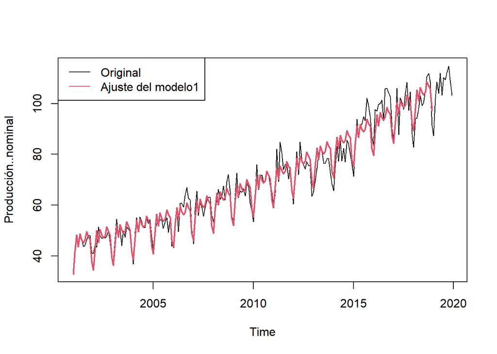

```r
plot(Datos20)
lines(mod1_ajust, col=2, lwd=2)
legend("topleft", legend = c("Original", "Ajuste del modelo1"), lty=1, col=c(1,2))
```

Modelo 2

```r
mod2_ajust <- ts(fitted(mod2), start  = c(2001,1), frequency = 12)
```

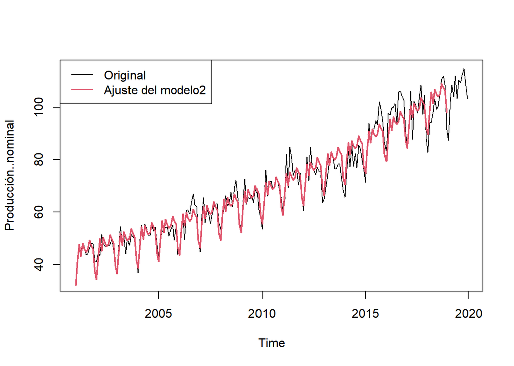

```r
plot(Datos20)
lines(mod2_ajust, col=2, lwd=2)
legend("topleft", legend = c("Original", "Ajuste del modelo2"), lty=1, col=c(1,2))
```

modelo 3

```r
mod3_Tt <- ts(fitted(mod3), start  = c(2001,1), frequency = 12)
mod3_ajust <- mod3_Tt + St # Ajuste D&LC(AICC)
```

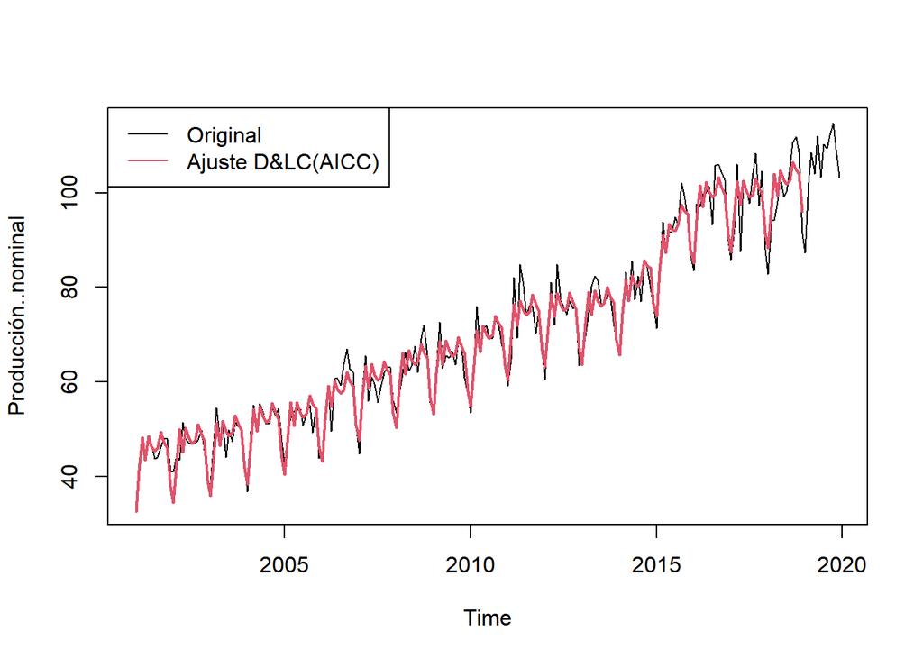

```r
plot(Datos20)
lines(mod3_ajust, col=2, lwd=2)
legend("topleft", legend = c("Original", "Ajuste D&LC(AICC)"), lty=1, col=c(1,2))
```

Modelo 4

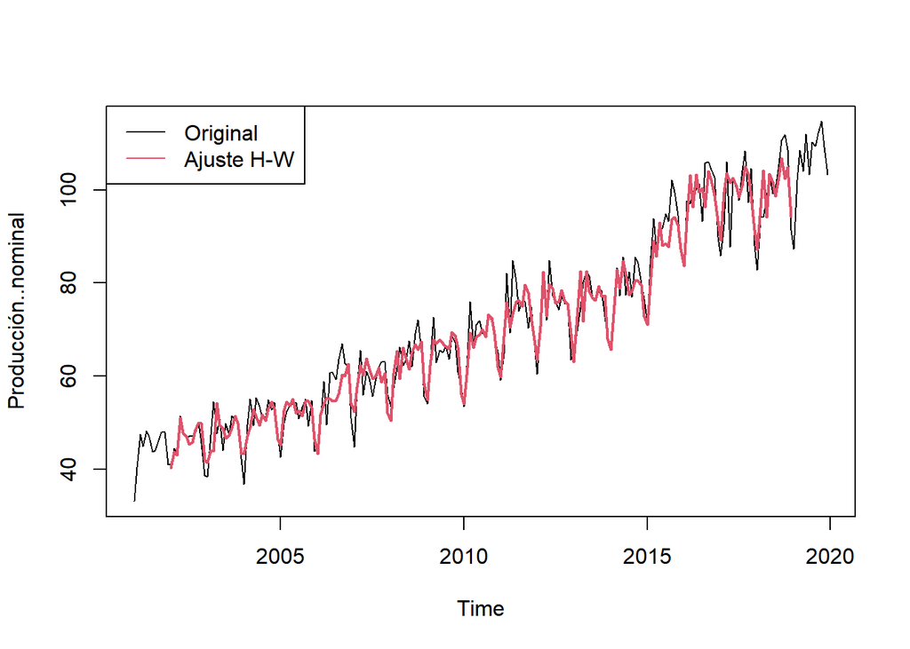

```r
mod4_ajust <- fitted(mod4)[,1]
plot(Datos20)
lines(mod4_ajust, col=2, lwd=2)
legend("topleft", legend=c("Original","Ajuste H-W"), col=c(1,2), lty=1)
```

# Calculo del AIC y BIC

```r
#Creando funci?n usuario crit.inf.resid() para calcular C^*_n(p)
crit.inf.resid <- function(residuales,n.par,AIC="TRUE"){
if(AIC=="TRUE"){
#Calcula AIC
CI=log(mean(residuales^2))+2*n.par/length(residuales)
}
if(AIC=="FALSE"){
#Calcula BIC
CI=log(mean(residuales^2))+n.par*log(length(residuales))/length(residuales)
}
CI
}
```

modelo 1

```r
resmod1.orig <- residuals(mod1) #seudo-residuos en la escala original. Usados s?lo para calcular AIC y BIC

npar1 <- length(coef(mod1)[coef(mod1)!=0]) #n?mero par?metros modelo 1

aic1 <- exp(crit.inf.resid(resmod1.orig,n.par=npar1))
bic1 <- exp(crit.inf.resid(resmod1.orig ,n.par=npar1, AIC="FALSE"))
```

modelo 2

```r
resmod2.orig <- residuals(mod2) #seudo-residuos en la escala original. Usados s?lo para calcular AIC y BIC

npar2 <- length(coef(mod2)[coef(mod2)!=0]) #n?mero par?metros modelo 1

aic2 <- exp(crit.inf.resid(resmod1.orig,n.par=npar2))
bic2 <- exp(crit.inf.resid(resmod1.orig ,n.par=npar2, AIC="FALSE"))
```

modelo 3

```r
et3 <- yt - mod3_ajust

p3 <- round(mod3$enp)+s-1
AIC3 <- exp(crit.inf.resid(residuales=et3,n.par=p3))
BIC3 <- exp(crit.inf.resid(residuales=et3,n.par=p3,AIC="FALSE"))
```

modelo 4

```r
p4 <- (s-1)+2 #Aprox. del n?mero de par?metros del suavizamiento
AIC4 <- exp(crit.inf.resid(residuales=residuals(mod4),n.par=p4))
BIC4 <- exp(crit.inf.resid(residuales=residuals(mod4),n.par=p4,AIC="FALSE"))
```

# Preguntas orientadas para los analisis

## hacer tablas de los summary

- En los modelos globales ¿Son significativos el polinomio considerado y la componente estacional con la representación que fue usada?

Modelo 1

Debido a que el valor ajustado para el coeficiente correspondiente al grado 2 del polinomio tiene un p-valor muy peque?o(menor a 0.05), se dice que es significativo y por lo tanto la estructura del polinomio cuadratico es significativa. Por otro lado, ya que al menos uno de los coeficientes estimados asociados a las variables indicadoras, son significativos(p-valor menor a 0.05), en este caso todos, se concluye que la componente estacional es significativa.

Modelo 2

Debido a que el valor ajustado para el coeficiente correspondiente al grado 3 del polinomio tiene un p-valor grande(mayor a 0.05), se dice que no es significativo y por lo tanto la estructura del polinomio cubico no es significativa. Por otro lado, ya que al menos uno de los coeficientes estimados asociados a las variables indicadoras, son significativos(p-valor menor a 0.05), en este caso todos, se concluye que la componente estacional es significativa.

En los modelos globales ¿Cuál es la interpretación de las estimaciones de los parámetros estacionales?, ¿difieren mucho estas estimaciones entre los modelos globales? Además, si se modelo con variables indicadoras, grafique en un mismo plano y en la escala original de la serie, el patrón estacional estimado ¿Estas estimaciones aproximan apropiadamente el patrón estacional? Esta gráfica puede realizarse de la siguiente manera: Suponga que los modelos son ajustados en R bajo los objetos de nombre mod1 y mod2 respectivamente. Sean p1 y p2 los ordenes de los respectivos polinomios, nparmod1 y nparmod2 el número de parámetros, de cada modelo, respectivamente. En el caso aditivo, proceda así:

Ya que la serie es aditiva, los $\delta_i$ es la diferencia entre la media de la serie en el mes i del año menos la media en el periodo de referencia, es decir, diciembre.

```r
summary(mod1)
```

```
##
## Call:
## lm(formula = yt ~ t + I(t^2) + I1 + I2 + I3 + I4 + I5 + I6 +
##     I7 + I8 + I9 + I10 + I11)
##
## Residuals:
##      Min       1Q   Median       3Q      Max
## -11.2796  -2.4057  -0.1672   2.2769  11.0489
##
## Coefficients:
##               Estimate Std. Error t value Pr(>|t|)
## (Intercept)  3.582e+01  1.225e+00  29.243  < 2e-16 ***
## t            1.320e-01  1.745e-02   7.564 1.35e-12 ***
## I(t^2)       7.051e-04  7.787e-05   9.055  < 2e-16 ***
## I1          -3.182e+00  1.327e+00  -2.397   0.0174 *
## I2           5.307e+00  1.327e+00   3.999 8.93e-05 ***
## I3           1.202e+01  1.327e+00   9.059  < 2e-16 ***
## I4           7.269e+00  1.327e+00   5.478 1.27e-07 ***
## I5           1.211e+01  1.327e+00   9.130  < 2e-16 ***
## I6           9.826e+00  1.327e+00   7.406 3.47e-12 ***
## I7           8.429e+00  1.327e+00   6.354 1.37e-09 ***
## I8           9.093e+00  1.327e+00   6.854 8.50e-11 ***
## I9           1.252e+01  1.327e+00   9.435  < 2e-16 ***
## I10          1.055e+01  1.327e+00   7.953 1.28e-13 ***
## I11          8.948e+00  1.326e+00   6.745 1.57e-10 ***
## ---
## Signif. codes:  0 '***' 0.001 '**' 0.01 '*' 0.05 '.' 0.1 ' ' 1
##
## Residual standard error: 3.979 on 202 degrees of freedom
## Multiple R-squared:  0.9589, Adjusted R-squared:  0.9562
## F-statistic: 362.3 on 13 and 202 DF,  p-value: < 2.2e-16
```

```r
summary(mod2)
```

```
##
## Call:
## lm(formula = yt ~ t + I(t^2) + I(t^3) + I1 + I2 + I3 + I4 + I5 +
##     I6 + I7 + I8 + I9 + I10 + I11)
##
## Residuals:
##      Min       1Q   Median       3Q      Max
## -11.6505  -2.3126  -0.1508   2.1501  11.1269
##
## Coefficients:
##               Estimate Std. Error t value Pr(>|t|)
## (Intercept)  3.511e+01  1.452e+00  24.184  < 2e-16 ***
## t            1.690e-01  4.405e-02   3.836 0.000168 ***
## I(t^2)       2.800e-04  4.712e-04   0.594 0.552936
## I(t^3)       1.306e-06  1.428e-06   0.915 0.361432
## I1          -3.115e+00  1.330e+00  -2.342 0.020160 *
## I2           5.368e+00  1.329e+00   4.038 7.67e-05 ***
## I3           1.208e+01  1.329e+00   9.088  < 2e-16 ***
## I4           7.318e+00  1.329e+00   5.508 1.10e-07 ***
## I5           1.216e+01  1.328e+00   9.153  < 2e-16 ***
## I6           9.862e+00  1.328e+00   7.427 3.10e-12 ***
## I7           8.460e+00  1.328e+00   6.372 1.25e-09 ***
## I8           9.118e+00  1.327e+00   6.869 7.93e-11 ***
## I9           1.253e+01  1.327e+00   9.444  < 2e-16 ***
## I10          1.056e+01  1.327e+00   7.958 1.25e-13 ***
## I11          8.954e+00  1.327e+00   6.747 1.57e-10 ***
## ---
## Signif. codes:  0 '***' 0.001 '**' 0.01 '*' 0.05 '.' 0.1 ' ' 1
##
## Residual standard error: 3.981 on 201 degrees of freedom
## Multiple R-squared:  0.959,  Adjusted R-squared:  0.9562
## F-statistic: 336.2 on 14 and 201 DF,  p-value: < 2.2e-16
```

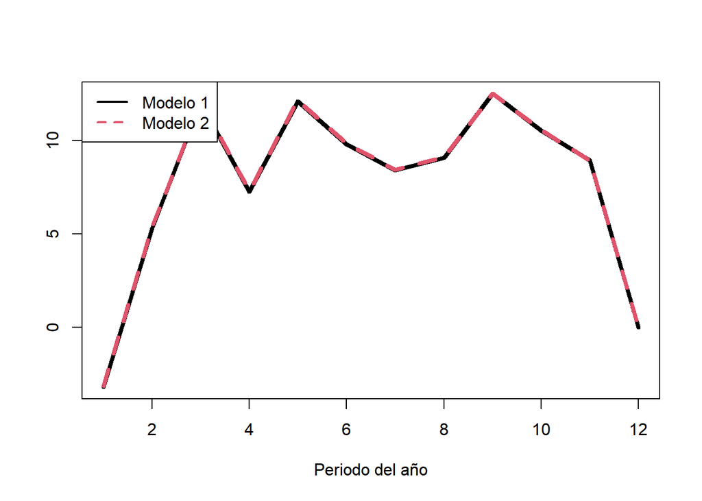

```r
p1 <- 2 # grado del polinomio modelo 1
p2 <- 3 # grado del polinomio modelo 2


efectosestac1 <- ts(c(coef(mod1)[(p1+2):npar1],0),freq=1,start=1)
efectosestac2 <- ts(c(coef(mod2)[(p2+2):npar2],0),freq=1,start=1)
#win.graph()
plot(efectosestac1,lwd=4,ylab="",xlab="Periodo del año")
lines(efectosestac2,lty=2,col=2,lwd=4)
legend("topleft",legend=c("Modelo 1","Modelo 2"),col=1:2,lty=1:2,lwd=2)
```

Vemos que el mod1 y el mod2 estiman la misma forma para $S_t$ además de que sus valores son muy similares para los efectos estacionales (no son iguales pero tinen diferencias muy pequeñas en las estimaciones de los $\delta_i$)

- Compare gráficamente la forma de la estimación de la componente estacional entre los dos modelos locales(en Holt-Winters se toma el último valor suavizado para cada uno de los 12 efectos estacionales) ¿difieren mucho? Además, si en los modelos globales se usaron indicadoras, compare la forma del patrón estacional estimado por estos vs. los locales ¿qué se interpreta a partir de la similaridad o diferencia entre estas estimaciones?

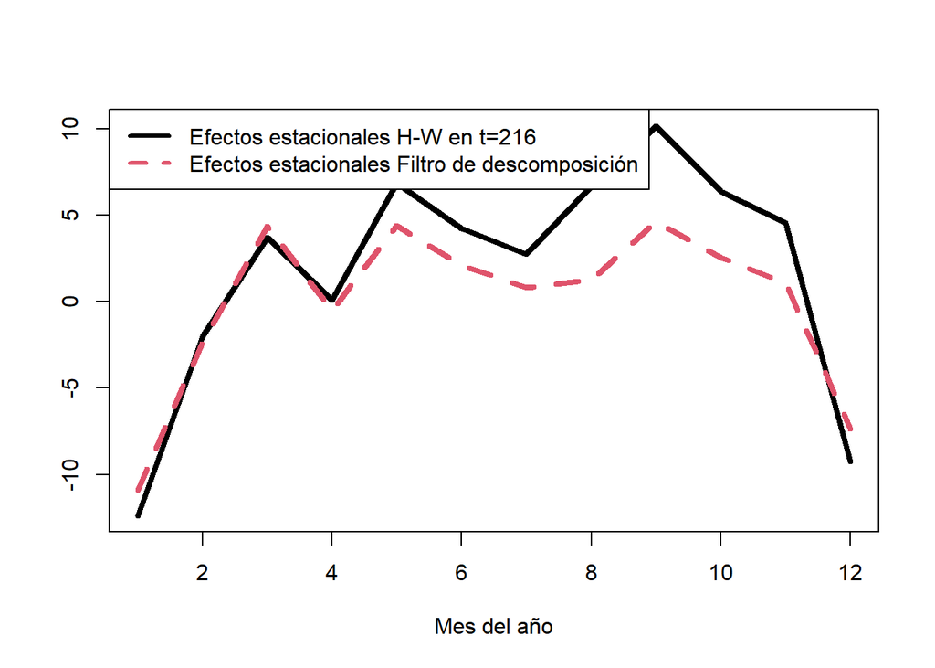

```r
#extracción estimaciones en t=216 de efectos estacionales segun Holt-Winters.

deltasiHW=ts(mod4$coef[c(3:14)],freq=1,start=1)#Estimaciones de los efectos estacionales segun filtro de descomposicióon

deltasDescomp=ts(deltas_i,freq=1,start=1)
deltasilocales=data.frame(rbind(deltasiHW,deltasDescomp),row.names=c("HW","Descomp&loess"))
names(deltasilocales)=c(1:12)#Gráfico de los efectos estacionales estimados


plot(deltasiHW,lwd=4,ylim=c(min(deltasiHW,deltasDescomp),max(deltasiHW,deltasDescomp)+0.05),ylab="",xlab="Mes del año")
lines(deltasDescomp,lty=2,lwd=4,col=2)
legend("topleft",legend=c("Efectos estacionales H-W en t=216","Efectos estacionales Filtro de descomposición"),col=1:2,lty=1:2,lwd=3)
```

- Se observa que hay algunas diferencias entre las estimaciones “globales” que da el filtro con respecto a “la última estimación local” que da SEHW; sin embargo, la “forma del patrón” estimado es igual. Por lo tanto, $S_t$ en $Y_t$ es más o menos estable en el tiempo.

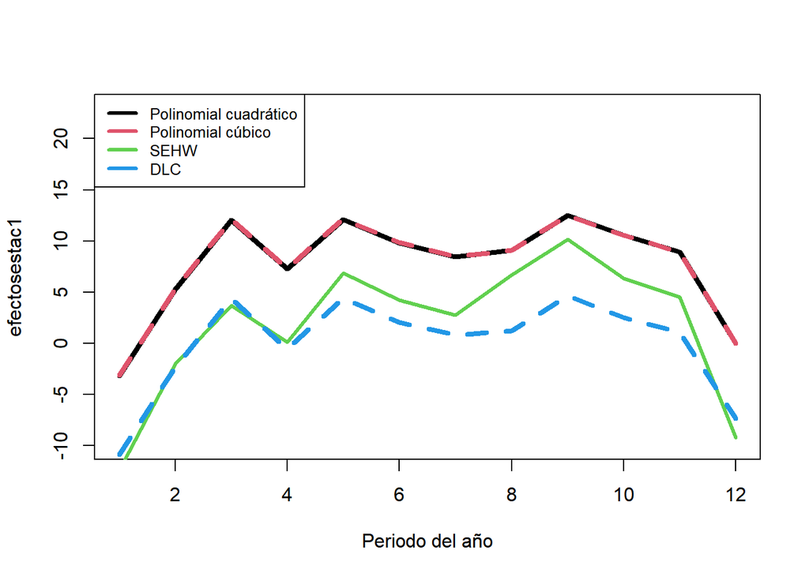

```r
plot(efectosestac1,lwd=4,xlab="Periodo del año", ylim =c(-10, 23))
lines(efectosestac2,lty=2,col=2,lwd=4)
lines(deltasiHW,lwd=3, col=3)
lines(deltasDescomp,lty=2,lwd=4,col=4)
legend("topleft",legend=c("Polinomial cuadrático","Polinomial cúbico", "SEHW","DLC"),col=1:4,lwd=3, cex=0.8)
```

Con relación al ajuste loess de la serie desestacionalizada ¿Qué se concluye de su gráfica y del número de parámetros equivalentes loess?

# GRÁFICOS DE LA SERIE DESESTACIONALIZADA Y SUS AJUSTES LOESS

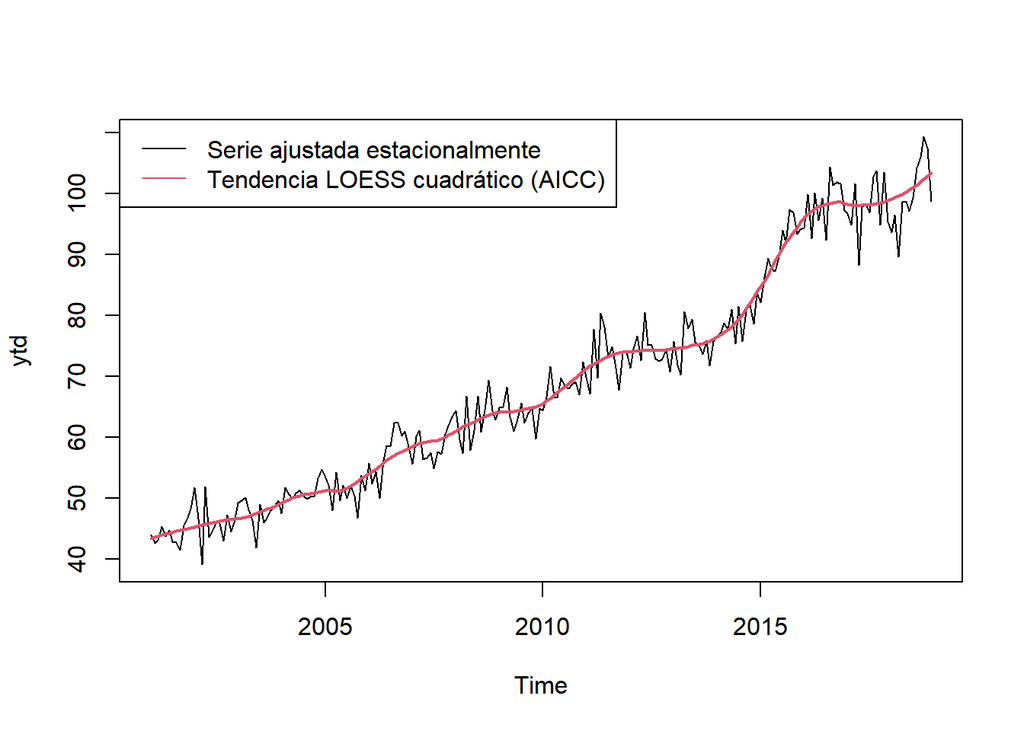

```r
plot(ytd)
lines(mod3_Tt, col=2, lwd = 2)
legend("topleft", legend=c("Serie ajustada estacionalmente", "Tendencia LOESS cuadrático (AICC)"), col=c(1,2), lty=1)
```

Se observa que los valores ajustados se acercan a los valores que toma la serie; la componente ciclica que toma la serie esta presente ya que se puede observar que la tendencia no es una curva completamente suave.

Finalmente el ajuste que hace LOESS al final de la serie es creciente, aunque el valor real muestra una tendencia decreciente

Para un ajuste global polinomial alcanzando el mismo ajuste que LOESS, el modelo global deberia ser un polinomial con aproximadamente 13 parámetros.

¿Qué se concluye sobre la calidad del ajuste de los modelos globales vs. locales? también determine entre los modelos globales cuál modelo recomendaría inicialmente como mejor modelo global para ajustar la serie. Tenga en cuenta no sólo los valores de los criterios de información, sino también los resultados gráficos.

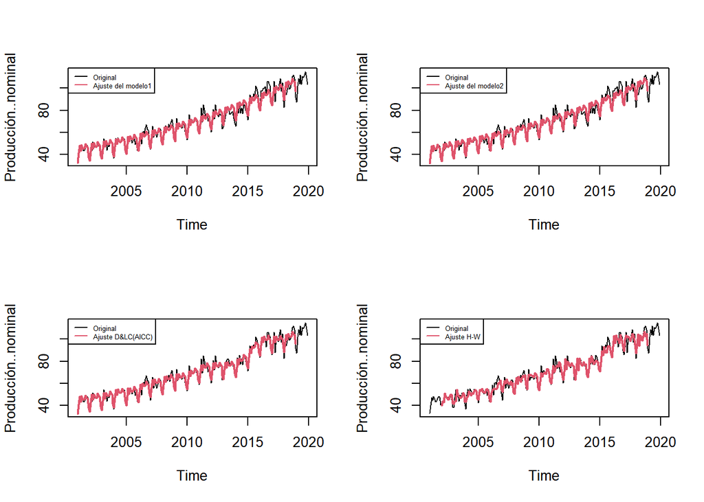

```r
par(mfrow=c(2,2))
plot(Datos20)
lines(mod1_ajust, col=2, lwd=2)
legend("topleft", legend = c("Original", "Ajuste del modelo1"), lty=1, col=c(1,2), cex=0.5)

plot(Datos20)
lines(mod2_ajust, col=2, lwd=2)
legend("topleft", legend = c("Original", "Ajuste del modelo2"), lty=1, col=c(1,2), cex=0.5)

plot(Datos20)
lines(mod3_ajust, col=2, lwd=2)
legend("topleft", legend = c("Original", "Ajuste D&LC(AICC)"), lty=1, col=c(1,2), cex=0.5)

plot(Datos20)
lines(mod4_ajust, col=2, lwd=2)
legend("topleft", legend=c("Original","Ajuste H-W"), col=c(1,2), lty=1, cex=0.5)
```

- En general mediante los gráficos tiene un mejor ajuste los modelos locales que los globales
- Entre los modelos globales se recomienda el modelo cuadrático con indicadoras ya que con un grado menos del polinomio ajusta igual de bien que el cúbico, por tanto se prefiere por ser un modelo más simple (parsimonioso) además que en los ajustes se noto que el grado 3 del polinomio del segundo modelo no es significativo.

# 4. Análisis de residuales y validación de supuestos: Para todos los modelos ajustados, globales y locales, realice el análisis comparativo de residuales.

Gráfico de los residuales en el tiempo

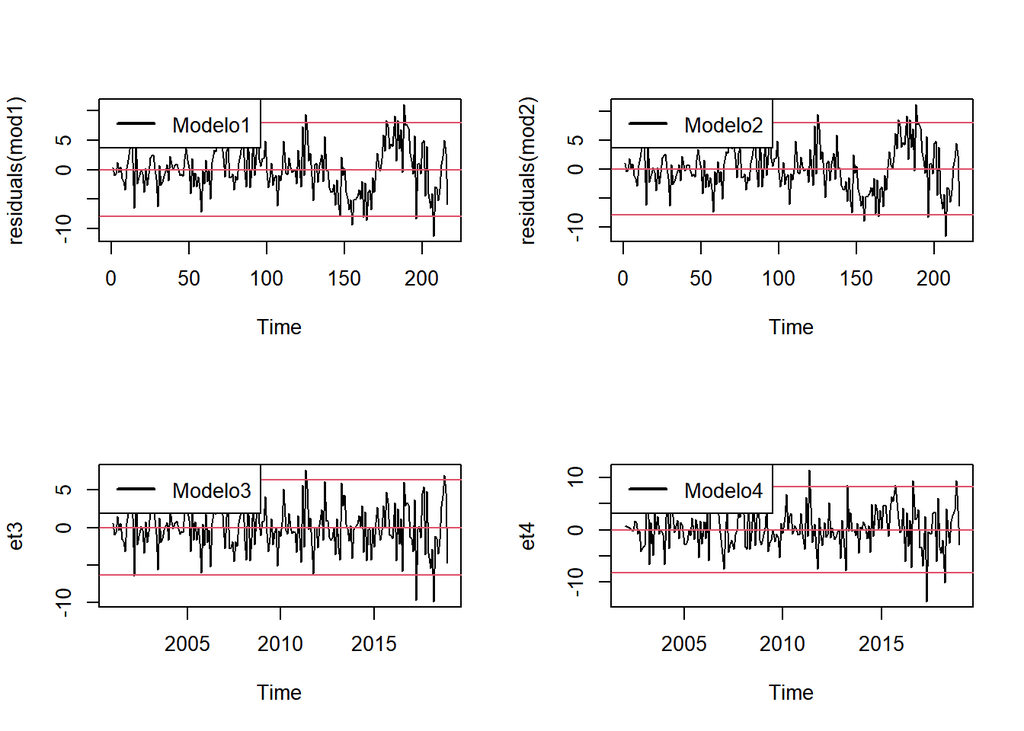

```r
par(mfrow=c(2,2))

# Residuales vs tiempo mod1
plot.ts(residuals(mod1))
abline(h=c(-2*summary(mod1)$sigma, 0, 2*summary(mod1)$sigma), col=2)
legend("topleft", legend=c("Modelo1"), lty=1, col = 1, lwd=2)


# Residuales vs tiempo mod2
plot.ts(residuals(mod2))
abline(h=c(-2*summary(mod2)$sigma, 0, 2*summary(mod2)$sigma), col=2)
legend("topleft", legend=c("Modelo2"), lty=1, col = 1, lwd=2)


# Residuales vs tiempo mod3
df=n-(round(mod3$enp)+s-1) #Grados de libertad aproximados del ajuste total
MSE3=sum(et3^2)/df #MSE aproximado del ajuste total del modelo 3
plot(et3,ylim=c(min(-2*sqrt(MSE3),et3),max(2*sqrt(MSE3),et3)))
abline(h=c(-2*sqrt(MSE3),0,2*sqrt(MSE3)),col=2)
legend("topleft", legend=c("Modelo3"), lty=1, col = 1, lwd=2)


# Residuales vs tiempo mod4

et4=residuals(mod4)
df4=n-2*s-((s-1)+2)
MSE4=mod4$SSE/df4 #MSE aproximado del ajuste total del Suavizamiento

plot(et4,ylim=c(min(-2*sqrt(MSE4),et4),max(2*sqrt(MSE4),et4)))
abline(h=c(-2*sqrt(MSE4),0,2*sqrt(MSE4)),col=2)
legend("topleft", legend=c("Modelo4"), lty=1, col = 1, lwd=2)
```

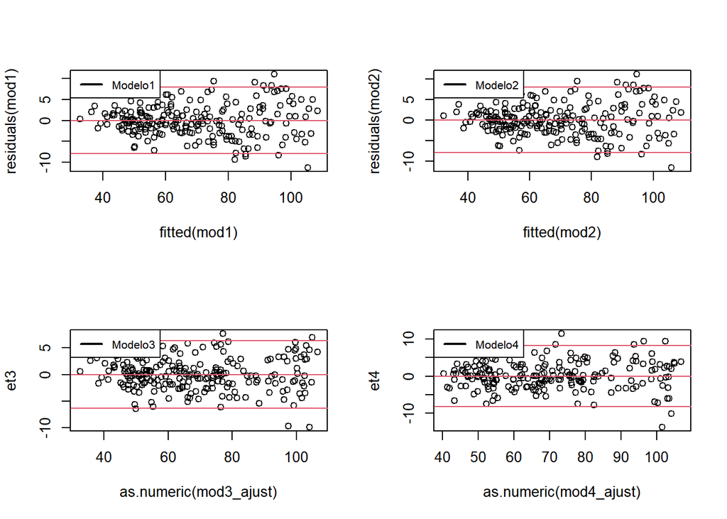

```r
par(mfrow=c(2,2))
# Residuales vs valores ajustados mod1

plot(fitted(mod1), residuals(mod1))
abline(h=c(-2*summary(mod1)$sigma, 0, 2*summary(mod1)$sigma), col=2)
legend("topleft", legend=c("Modelo1"), lty=1, col = 1, lwd=2,cex = 0.8)


# Residuales vs valores ajustados mod2

plot(fitted(mod2), residuals(mod2))
abline(h=c(-2*summary(mod2)$sigma, 0, 2*summary(mod2)$sigma), col=2)
legend("topleft", legend=c("Modelo2"), lty=1, col = 1, lwd=2,cex = 0.8)

# Residuales vs valores ajustados mod3
plot(as.numeric(mod3_ajust),et3,ylim=c(min(-2*sqrt(MSE3),et3),max(2*sqrt(MSE3),et3)))
abline(h=c(-2*sqrt(MSE3),0,2*sqrt(MSE3)),col=2)
legend("topleft", legend=c("Modelo3"), lty=1, col = 1, lwd=2,cex = 0.8)

# Residuales vs valores ajustados mod4

plot(as.numeric(mod4_ajust),et4,ylim=c(min(-2*sqrt(MSE4),et4),max(2*sqrt(MSE4),et4)))
abline(h=c(-2*sqrt(MSE4),0,2*sqrt(MSE4)),col=2)
legend("topleft", legend=c("Modelo4"), lty=1, col = 1, lwd=2,cex = 0.8)
```

- Sobre el supuesto de media cero para los errores de ajuste ¿qué se concluye en los cuatro modelos?

En las figuras presentadas en las gráficas de residuos vs. tiempo y vs. valores ajustados, no se observa evidencia contra el supuesto de que los errores tienen media cero (a pesar de la variación cíclica alrededor de cero, que se observa en las series de tiempo de los residuos de los modelos globales), pues en todos los casos los residuos parecen bien centrados en cero.

- ¿Es válido el supuesto de varianza constante en los 4 modelos?

- ¿Hay patrones en los residuos que indiquen carencia de ajuste de los modelos en la tendencia y/o la estacionalidad?

No hay evidencia de carencia de ajuste severa en las componentes estructurales (o sea en tendencia y estacionalidad), pues en los residuos vs. valores ajustados no se observan patrones claros con forma de U o de W que indiquen mal ajuste de la tendencia, ni patrones periódicos en las gráficas de las series de tiempo de residuos de ajuste que indiquen mal ajuste de la estacionalidad.

- ¿Hay ciclos presentes en los residuales? ¿qué se deriva de estos patrones?

En las series de tiempo de los residuos de los modelos globales hay evidencia de ciclos no explicados (los cuales se dan centrados en cero), esto implica que los errores en los modelos globales, separados un periodo en el tiempo, están positivamente correlacionados, es decir, $Corr(E_t,E_{t+1}) > 0$, por lo cual ya no es válido el supuesto de independencia.

Por el contrario, en las series de tiempo de los residuos de los dos modelos locales no son observables a simple vista patrones cíclicos, aunque esto no es una garantía suficiente para afirmar la validez de la independencia entre los errores de ajuste de estos dos modelos, es un punto su favor.

- ¿Qué hacen mejor los métodos locales vs. los globales?

Los métodos locales logran seguir ciclos, por eso son mejores que los modelos globales.

- ¿Cuál es el mejor modelo de los cuatro, de acuerdo al análisis de los residuales?

Con todo lo antes dicho, de los 4 modelos, se considera que los modelos de ajuste local son mejores, ya que en ellos no hay patrones cíclicos y por tanto dan indicios de cumplir el supuesto de independencia.

# 5. Pronósticos para la validación cruzada: Para todos los modelos de ajuste global y local presentados, presente los resultados y análisis de pronósticos puntuales y por intervalos.

#### Hacer tabla de ecuaciones de pronóstico

#### Tabla con los pronósticos

Modelo 1

```r
ytpron1 <- predict(mod1, newdata=data.frame(t=tnuevo, I1=I1n, I2=I2n, I3=I3n, I4=I4n, I5=I5n, I6=I6n, I7=I7n, I8=I8n, I9=I9n, I10=I10n, I11=I11n), interval="prediction")
ytpron1 <- ts(ytpron1,freq=12,start=c(2019,1))
ytpron1
```

```
##               fit       lwr      upr
## Jan 2019  94.4852  86.27520 102.6952
## Feb 2019 103.4126  95.19741 111.6279
## Mar 2019 110.5678 102.34725 118.7884
## Apr 2019 106.2564  98.03028 114.4825
## May 2019 111.5449 103.31316 119.7767
## Jun 2019 109.7001 101.46257 117.9377
## Jul 2019 108.7498 100.50627 116.9933
## Aug 2019 109.8606 101.61094 118.1102
## Sep 2019 113.7324 105.47658 121.9883
## Oct 2019 112.2154 103.95319 120.4777
## Nov 2019 111.0651 102.79632 119.3338
## Dec 2019 102.5703  94.29486 110.8457
```

Modelo 2

```r
ytpron2 <- predict(mod2, newdata=data.frame(t=tnuevo, I1=I1n, I2=I2n, I3=I3n, I4=I4n, I5=I5n, I6=I6n, I7=I7n, I8=I8n, I9=I9n, I10=I10n, I11=I11n), interval="prediction")
ytpron2 <- ts(ytpron2,freq=12,start=c(2019,1))
ytpron2
```

```
##                fit       lwr      upr
## Jan 2019  95.19725  86.84148 103.5530
## Feb 2019 104.15594  95.78241 112.5295
## Mar 2019 111.34331 102.95097 119.7356
## Apr 2019 107.06490  98.65269 115.4771
## May 2019 112.38738 103.95418 120.8206
## Jun 2019 110.57743 102.12208 119.0328
## Jul 2019 109.66281 101.18411 118.1415
## Aug 2019 110.81020 102.30691 119.3135
## Sep 2019 114.71959 106.19043 123.2487
## Oct 2019 113.24098 104.68463 121.7973
## Nov 2019 112.12994 103.54501 120.7149
## Dec 2019 103.67534  95.06044 112.2903
```

Modelo 3

```r
#Pronósticos de la tendencia por loess cuadrático óptimo (AICC)
Ttnuevo3 <- predict(loess(ytd~t,span=alfa.optim2,degree=2,control=loess.control(surface="direct")),
data.frame(t=tnuevo),se=FALSE)
Ttnuevo3 <- ts(Ttnuevo3,freq=12,start=c(2019,1)) #convirtiendo en serie de tiempo al pronóstico de Tt, modelo 3
ytpron3 <- Ttnuevo3 + Stnuevo #Pronóstico puntual Modelo 2
#Tabla con pronósticos de las componentes y de la serie, Modelo 2
tablapron3 <- cbind(Pron_Tt=Ttnuevo3,Pron_St=Stnuevo,Pron_serie=ytpron3)
tablapron3
```

```
##           Pron_Tt     Pron_St Pron_serie
## Jan 2019 103.9982 -10.8780433   93.12013
## Feb 2019 104.6239  -2.3143178  102.30959
## Mar 2019 105.2877   4.3650940  109.65277
## Apr 2019 105.9900  -0.5319649  105.45802
## May 2019 106.7313   4.3979371  111.12925
## Jun 2019 107.5121   2.0783292  109.59040
## Jul 2019 108.3326   0.7969567  109.12959
## Aug 2019 109.1933   1.2373979  110.43074
## Sep 2019 110.0945   4.6148489  114.70934
## Oct 2019 111.0364   2.5229371  113.55930
## Nov 2019 112.0192   1.0633783  113.08259
## Dec 2019 113.0433  -7.3525531  105.69070
```

Modelo 4

```r
pronos4 <- predict(mod4, n.ahead=12,prediction=T,level=0.95)
ytpron4 <- pronos4[,1] #sólo los pronósticos puntuales del suavizamiento
```

Preguntas orientadas

- ¿Cuál es la interpretación de los pronósticos puntuales y sus I.P? Ejemplificar con una fecha y comparar entre modelos.

# Medidas en todos los modelos

```r
accuracy(ytpron1,ytnuevo) #Modelo 1
```

```
##                 ME     RMSE      MAE       MPE    MAPE       ACF1 Theil's U
## Test set -1.496726 3.153708 2.366654 -1.557341 2.33806 -0.2868274 0.3129704
```

```r
accuracy(ytpron2,ytnuevo) #Modelo 2
```

```
##                 ME     RMSE      MAE       MPE     MAPE       ACF1 Theil's U
## Test set -2.397089 3.620468 2.746457 -2.403396 2.711682 -0.3271882 0.3727997
```

```r
accuracy(ytpron3,ytnuevo) #Modelo 3
```

```
##               ME     RMSE     MAE       MPE     MAPE       ACF1 Theil's U
## Test set -1.8052 3.014298 2.33551 -1.811044 2.283224 -0.5026492 0.3247962
```

```r
accuracy(ytpron4,ytnuevo) #Modelo 4
```

```
##                 ME     RMSE      MAE     MPE     MAPE       ACF1 Theil's U
## Test set 0.6606291 3.187973 2.670446 0.56526 2.533667 -0.3579133  0.414068
```

Interpretaciones:

- Modelo 1:

En promedio en cada pronostico se estima un error de +- 3.153708 puntos del indice de producción nominal según el RMSE y de +- 2.366654 puntos del indice de producció nominal según MAE, mientras que MAPE estima que en promedio cada pronostico se comete un error de +-2.338% con relación al valor real del indice de producción nominal, todo esto en el modelo de regresión cuadrático con variables indicadores

- Modelo 2:

En promedio en cada pronostico se estima un error de +- 3.620468 puntos del indice de producción nominal según el RMSE y de +- 2.746457 puntos del indice de producció nominal según MAE, mientras que MAPE estima que en promedio cada pronostico se comete un error de +- 2.71% con relación al valor real del indice de producción nominal, todo esto en el modelo de regresión cúbico con variables indicadores.

- Modelo 3:

En promedio en cada pronostico se estima un error de +- 3.014298 puntos del indice de producción nominal según el RMSE y de +- 2.33551 puntos del indice de producció nominal según MAE, mientras que MAPE estima que en promedio cada pronostico se comete un error de +- 2.28% con relación al valor real del indice de producción nominal, todo esto en el modelo de Filtro de decomposición combinado Loess cuadrático.

- Modelo 4:

En promedio en cada pronostico se estima un error de +- 3.187973 puntos del indice de producción nominal según el RMSE y de +- 2.670446 puntos del indice de producció nominal según MAE, mientras que MAPE estima que en promedio cada pronostico se comete un error de +- 2.53% con relación al valor real del indice de producción nominal, todo esto en el modelo de SEHW.

- Con base en la amplitud media y cobertura de los I.P ¿qué se concluye?

```r
#Creando función usuario amplitud() para calcular la amplitud promedio de los I.P en pronósticos ex – post
amplitud=function(LIP,LSP){
a=LSP-LIP
am=mean(a)
am
}
#Creando función usuario cobertura() para calcular la cobertura de los I.P en pronósticos ex – post
cobertura=function(real,LIP,LSP){
I=ifelse(real>=LIP & real<=LSP,1,0)
p=mean(I)
p
}
```

Modelo 1:

```r
amplitud(LIP=ytpron1[,2],LSP=ytpron1[,3])
```

```
## [1] 16.48278
```

```r
cobertura(real=ytnuevo,LIP=ytpron1[,2],LSP=ytpron1[,3])
```

```
## [1] 1
```

Modelo 2:

```r
amplitud(LIP=ytpron2[,2],LSP=ytpron2[,3])
```

```
## [1] 16.94829
```

```r
cobertura(real=ytnuevo,LIP=ytpron2[,2],LSP=ytpron2[,3])
```

```
## [1] 1
```

Modelo 4:

```r
#Precisión pronósticos por I.P Holt-Winters

amplitud(LIP=pronos4[,3],LSP=pronos4[,2])
```

```
## [1] 17.22162
```

```r
cobertura(real=ytnuevo,LIP=pronos4[,3],LSP=pronos4[,2])
```

```
## [1] 1
```

Según este criterio todos los modelos que tienen intervalo de predicción tienen una cubertura del 100%, es decir todos los valores reales caen en el intervalo.

El modelo 1 es el de menor amplitud, por lo tanto según este criterio seria el mejor modelo.

- ¿Qué se concluye de la figura comparativa de los pronósticos puntuales?

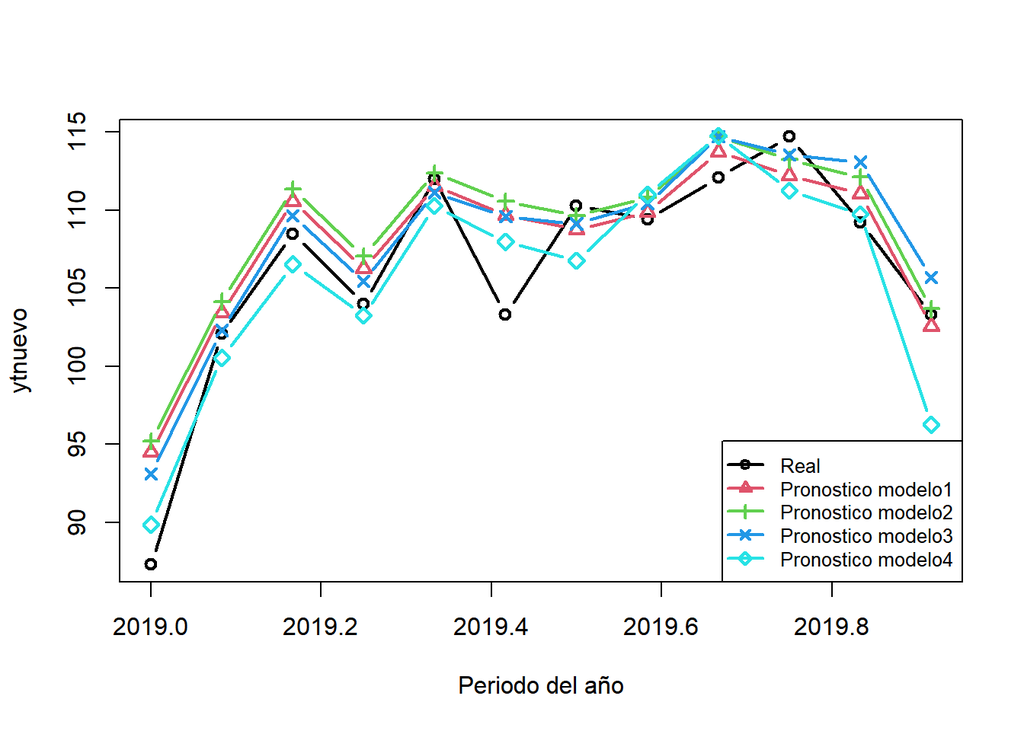

```r
plot(ytnuevo,lwd=2, col=1, type="b", pch=1, xlab="Periodo del año")
lines(ytpron1[,1],lwd=2, col=2, type="b", pch=2)
lines(ytpron2[,1],lwd=2, col=3, type="b", pch=3)
lines(ytpron3,lwd=2,col=4, type="b", pch=4)
lines(ytpron4,lwd=2,col=5, type="b", pch=5)
legend("bottomright",legend=c("Real","Pronostico modelo1", "Pronostico modelo2", "Pronostico modelo3", "Pronostico modelo4"),col=1:5,lwd=2, pch=1:5, cex=0.8)
```

- En base a la gráfica de pronosticos se escoge como mejor modelo el modelo 3.

# 6. Conclusiones del trabajo:

En esta sección debe presentar un resumen de los resultados encontrados en el respectivo trabajo, así como enunciar los problemas enfrentados en la modelación, postular cuál ha sido el mejor modelo en ajuste y pronóstico entre los tratados y comentar acerca de lo que usted crea que logró este mejor modelo:

- ¿Capturó la dinámica de la serie?
- ¿Su tendencia, estacionalidad y sus variaciones cíclicas son bien ajustadas?
- ¿Los pronósticos parecen realistas y confiables?
- ¿Qué otras alternativas podrían haberse propuesto?
- ¿Críticas al mejor modelo que encontró en el trabajo actual?
- Exprese claramente qué recomienda para la serie en cuanto a ajustes globales o locales, según lo realizado hasta el momento.